# Visualizing ATR OPUS binary files and DPT files in R

Adrianne Seiden

2025-10-07

# Reading OPUS files

[source](https://spectral-cockpit.github.io/opusreader2/articles/opusreader2_introduction.html)

This code is modified from the original OPUSreader2 documentation vignettes/opusreader2_introduction.Rmd by Philip Baumann and Thomas Knecht. It reads OPUS binary files and extracts metadata and absorbance data, which can then be plotted.

## Plots & Metadata

The main function, `read_opus()`, reads one or more OPUS files and returns a nested list of class `list_opusreader2`. Each list contains both the spectral data and metadata for each file. The `dsn` argument is the data source name. It can be a character vector of folder paths (to read files recursively) or specific OPUS file paths. Start by testing the read_opus function on your corrected spectra folder, and saving the output of the first file.

```r
#load opusreader2 from github.com/spectral-cockpit
library(opusreader2)

#save the data from your corrected files as 'data_test'
data_test <- read_opus(dsn = corr_spectra)
#check the names of the list
names(data_test)
>  [1] "pot028_13C_wheat_wk0_soil_241205.0"
>  [2] "pot050_13C_soy_wk0_soil_241205.0"
>  [3] "pot055_13C_rice_wk10_root_241205.0"
>  [4] "pot055_13C_rice_wk10_soil_241205.0"
>  [5] "pot062_13C_soy_wk0_root_241205.0"
>  [6] "pot062_13C_soy_wk0_soil_241205.0"
>  [7] "pot072_12C_noPlant_wk0_soil_241205.0"
>  [8] "pot079_13C_rice_wk0_soil_241205.0"
>  [9] "pot080_13C_soy_wk10_root_241205.0"
> [10] "pot080_13C_soy_wk10_soil_241205.0"
> [11] "pot087_13C_rice_wk10_soil_241205.0"
> [12] "pot094_13C_soy_wk10_root_241205.0"
> [13] "pot094_13C_soy_wk10_soil_241205.0"
> [14] "pot103_13C_rice_wk0_soil_241205.0"
> [15] "pot119_13C_rice_wk10_soil_241205.0"
# define 'meas_1' as the first element of the 'data_test' list
meas_1 <- data_test[[1]]
```

Next I defined a function, plotSpectrum, to plot the spectral data from a single sample (meas_1)

```r
# data is a list containing OPUS file data, including absorbance and metadata.

plotSpectrum <- function(data) { # nolint: object_name_linter.
  ab_data <- data$ab
  if (!is.null(ab_data) &&
        !is.null(ab_data$wavenumbers) && !is.null(ab_data$data) &&
        is.numeric(ab_data$wavenumbers) && is.numeric(ab_data$data) &&
        length(ab_data$wavenumbers) == length(ab_data$data) &&
        all(is.finite(ab_data$wavenumbers)) && all(is.finite(ab_data$data))) {
    plot(
      ab_data$wavenumbers, ab_data$data, type = "l",
      xlab = "Wavenumber (cm⁻¹)", ylab = "Absorbance",
      main = data$basic_metadata$dsn_filename,
      xlim = rev(range(ab_data$wavenumbers))
    )
  } else {
    cat("Absorbance data not found or not valid in this file.\n")
    str(ab_data)
  }
}
plotSpectrum(meas_1)
> Absorbance data not found or not valid in this file.
>  NULL
```

To view all the available data categories, run ‘names(meas_1)’ in the console. To view the parameters within these categories use str(meas_1$category_name) where ‘category_name’ is ‘basic_metadata’, ‘optics’, etc.

### Metadata table (folder)

```r
for (i in seq_along(data_test)) {
  cat("#### Spectrum", i, ":", names(data_test)[i], "\n\n")
  data_i <- data_test[[i]]
  print(metadataTable(data_i))
}
> #### Spectrum 1 : pot028_13C_wheat_wk0_soil_241205.0
>
>
>
> Table: Metadata
>
> |Parameter           |Value                              |
> |:-------------------|:----------------------------------|
> |File Name           |pot028_13C_wheat_wk0_soil_241205.0 |
> |Timestamp           |2024-12-06 00:15:54 GMT-8          |
> |Max Y               |NA                                 |
> |Min Y               |NA                                 |
> |Aperture Setting    |6 mm                               |
> |Scanner Velocity    |10.0S                              |
> |Result Spectrum     |ATR                                |
> |Resolution          |4                                  |
> |Sample Scans        |64                                 |
> |End Frequency       |400                                |
> |Start Frequency     |4000                               |
> |Duration            |58.22998046875                     |
> |Experiment (method) |Base_soils_method_SSC.xpm          |
> #### Spectrum 2 : pot050_13C_soy_wk0_soil_241205.0
>
>
>
> Table: Metadata
>
> |Parameter           |Value                            |
> |:-------------------|:--------------------------------|
> |File Name           |pot050_13C_soy_wk0_soil_241205.0 |
> |Timestamp           |2024-12-06 00:15:54 GMT-8        |
> |Max Y               |NA                               |
> |Min Y               |NA                               |
> |Aperture Setting    |6 mm                             |
> |Scanner Velocity    |10.0S                            |
> |Result Spectrum     |ATR                              |
> |Resolution          |4                                |
> |Sample Scans        |64                               |
> |End Frequency       |400                              |
> |Start Frequency     |4000                             |
> |Duration            |58.22998046875                   |
> |Experiment (method) |Base_soils_method_SSC.xpm        |
> #### Spectrum 3 : pot055_13C_rice_wk10_root_241205.0
>
>
>
> Table: Metadata
>
> |Parameter           |Value                              |
> |:-------------------|:----------------------------------|
> |File Name           |pot055_13C_rice_wk10_root_241205.0 |
> |Timestamp           |2024-12-06 00:22:32 GMT-8          |
> |Max Y               |NA                                 |
> |Min Y               |NA                                 |
> |Aperture Setting    |6 mm                               |
> |Scanner Velocity    |10.0S                              |
> |Result Spectrum     |ATR                                |
> |Resolution          |4                                  |
> |Sample Scans        |64                                 |
> |End Frequency       |400                                |
> |Start Frequency     |4000                               |
> |Duration            |58.2289733886719                   |
> |Experiment (method) |Base_soils_method_SSC.xpm          |
> #### Spectrum 4 : pot055_13C_rice_wk10_soil_241205.0
>
>
>
> Table: Metadata
>
> |Parameter           |Value                              |
> |:-------------------|:----------------------------------|
> |File Name           |pot055_13C_rice_wk10_soil_241205.0 |
> |Timestamp           |2024-12-06 00:28:30 GMT-8          |
> |Max Y               |NA                                 |
> |Min Y               |NA                                 |
> |Aperture Setting    |6 mm                               |
> |Scanner Velocity    |10.0S                              |
> |Result Spectrum     |ATR                                |
> |Resolution          |4                                  |
> |Sample Scans        |64                                 |
> |End Frequency       |400                                |
> |Start Frequency     |4000                               |
> |Duration            |58.2289733886719                   |
> |Experiment (method) |Base_soils_method_SSC.xpm          |
> #### Spectrum 5 : pot062_13C_soy_wk0_root_241205.0
>
>
>
> Table: Metadata
>
> |Parameter           |Value                            |
> |:-------------------|:--------------------------------|
> |File Name           |pot062_13C_soy_wk0_root_241205.0 |
> |Timestamp           |2024-12-06 00:28:30 GMT-8        |
> |Max Y               |NA                               |
> |Min Y               |NA                               |
> |Aperture Setting    |6 mm                             |
> |Scanner Velocity    |10.0S                            |
> |Result Spectrum     |ATR                              |
> |Resolution          |4                                |
> |Sample Scans        |64                               |
> |End Frequency       |400                              |
> |Start Frequency     |4000                             |
> |Duration            |58.2289733886719                 |
> |Experiment (method) |Base_soils_method_SSC.xpm        |
> #### Spectrum 6 : pot062_13C_soy_wk0_soil_241205.0
>
>
>
> Table: Metadata
>
> |Parameter           |Value                            |
> |:-------------------|:--------------------------------|
> |File Name           |pot062_13C_soy_wk0_soil_241205.0 |
> |Timestamp           |2024-12-06 00:28:30 GMT-8        |
> |Max Y               |NA                               |
> |Min Y               |NA                               |
> |Aperture Setting    |6 mm                             |
> |Scanner Velocity    |10.0S                            |
> |Result Spectrum     |ATR                              |
> |Resolution          |4                                |
> |Sample Scans        |64                               |
> |End Frequency       |400                              |
> |Start Frequency     |4000                             |
> |Duration            |58.2289733886719                 |
> |Experiment (method) |Base_soils_method_SSC.xpm        |
> #### Spectrum 7 : pot072_12C_noPlant_wk0_soil_241205.0
>
>
>
> Table: Metadata
>
> |Parameter           |Value                                |
> |:-------------------|:------------------------------------|
> |File Name           |pot072_12C_noPlant_wk0_soil_241205.0 |
> |Timestamp           |2024-12-06 00:15:02 GMT-8            |
> |Max Y               |NA                                   |
> |Min Y               |NA                                   |
> |Aperture Setting    |6 mm                                 |
> |Scanner Velocity    |10.0S                                |
> |Result Spectrum     |ATR                                  |
> |Resolution          |4                                    |
> |Sample Scans        |256                                  |
> |End Frequency       |400                                  |
> |Start Frequency     |4000                                 |
> |Duration            |233.10595703125                      |
> |Experiment (method) |Base_soils_method_SSC.xpm            |
> #### Spectrum 8 : pot079_13C_rice_wk0_soil_241205.0
>
>
>
> Table: Metadata
>
> |Parameter           |Value                             |
> |:-------------------|:---------------------------------|
> |File Name           |pot079_13C_rice_wk0_soil_241205.0 |
> |Timestamp           |2024-12-06 00:28:30 GMT-8         |
> |Max Y               |NA                                |
> |Min Y               |NA                                |
> |Aperture Setting    |6 mm                              |
> |Scanner Velocity    |10.0S                             |
> |Result Spectrum     |ATR                               |
> |Resolution          |4                                 |
> |Sample Scans        |64                                |
> |End Frequency       |400                               |
> |Start Frequency     |4000                              |
> |Duration            |58.2289733886719                  |
> |Experiment (method) |Base_soils_method_SSC.xpm         |
> #### Spectrum 9 : pot080_13C_soy_wk10_root_241205.0
>
>
>
> Table: Metadata
>
> |Parameter           |Value                             |
> |:-------------------|:---------------------------------|
> |File Name           |pot080_13C_soy_wk10_root_241205.0 |
> |Timestamp           |2024-12-06 00:28:30 GMT-8         |
> |Max Y               |NA                                |
> |Min Y               |NA                                |
> |Aperture Setting    |6 mm                              |
> |Scanner Velocity    |10.0S                             |
> |Result Spectrum     |ATR                               |
> |Resolution          |4                                 |
> |Sample Scans        |64                                |
> |End Frequency       |400                               |
> |Start Frequency     |4000                              |
> |Duration            |58.2309875488281                  |
> |Experiment (method) |Base_soils_method_SSC.xpm         |
> #### Spectrum 10 : pot080_13C_soy_wk10_soil_241205.0
>
>
>
> Table: Metadata
>
> |Parameter           |Value                             |
> |:-------------------|:---------------------------------|
> |File Name           |pot080_13C_soy_wk10_soil_241205.0 |
> |Timestamp           |2024-12-06 00:22:47 GMT-8         |
> |Max Y               |NA                                |
> |Min Y               |NA                                |
> |Aperture Setting    |6 mm                              |
> |Scanner Velocity    |10.0S                             |
> |Result Spectrum     |ATR                               |
> |Resolution          |4                                 |
> |Sample Scans        |64                                |
> |End Frequency       |400                               |
> |Start Frequency     |4000                              |
> |Duration            |22.7099914550781                  |
> |Experiment (method) |Base_soils_method_SSC.xpm         |
> #### Spectrum 11 : pot087_13C_rice_wk10_soil_241205.0
>
>
>
> Table: Metadata
>
> |Parameter           |Value                              |
> |:-------------------|:----------------------------------|
> |File Name           |pot087_13C_rice_wk10_soil_241205.0 |
> |Timestamp           |2024-12-06 00:28:30 GMT-8          |
> |Max Y               |NA                                 |
> |Min Y               |NA                                 |
> |Aperture Setting    |6 mm                               |
> |Scanner Velocity    |10.0S                              |
> |Result Spectrum     |ATR                                |
> |Resolution          |4                                  |
> |Sample Scans        |64                                 |
> |End Frequency       |400                                |
> |Start Frequency     |4000                               |
> |Duration            |58.22998046875                     |
> |Experiment (method) |Base_soils_method_SSC.xpm          |
> #### Spectrum 12 : pot094_13C_soy_wk10_root_241205.0
>
>
>
> Table: Metadata
>
> |Parameter           |Value                             |
> |:-------------------|:---------------------------------|
> |File Name           |pot094_13C_soy_wk10_root_241205.0 |
> |Timestamp           |2024-12-06 00:28:30 GMT-8         |
> |Max Y               |NA                                |
> |Min Y               |NA                                |
> |Aperture Setting    |6 mm                              |
> |Scanner Velocity    |10.0S                             |
> |Result Spectrum     |ATR                               |
> |Resolution          |4                                 |
> |Sample Scans        |64                                |
> |End Frequency       |400                               |
> |Start Frequency     |4000                              |
> |Duration            |58.2289733886719                  |
> |Experiment (method) |Base_soils_method_SSC.xpm         |
> #### Spectrum 13 : pot094_13C_soy_wk10_soil_241205.0
```

```r
>
>
>
> Table: Metadata
>
> |Parameter           |Value                             |
> |:-------------------|:---------------------------------|
> |File Name           |pot094_13C_soy_wk10_soil_241205.0 |
> |Timestamp           |2024-12-06 00:28:30 GMT-8         |
> |Max Y               |NA                                |
> |Min Y               |NA                                |
> |Aperture Setting    |6 mm                              |
> |Scanner Velocity    |10.0S                             |
> |Result Spectrum     |ATR                               |
> |Resolution          |4                                 |
> |Sample Scans        |64                                |
> |End Frequency       |400                               |
> |Start Frequency     |4000                              |
> |Duration            |58.22998046875                    |
> |Experiment (method) |Base_soils_method_SSC.xpm         |
> #### Spectrum 14 : pot103_13C_rice_wk0_soil_241205.0
>
>
>
> Table: Metadata
>
> |Parameter           |Value                             |
> |:-------------------|:---------------------------------|
> |File Name           |pot103_13C_rice_wk0_soil_241205.0 |
> |Timestamp           |2024-12-06 00:28:30 GMT-8         |
> |Max Y               |NA                                |
> |Min Y               |NA                                |
> |Aperture Setting    |6 mm                              |
> |Scanner Velocity    |10.0S                             |
> |Result Spectrum     |ATR                               |
> |Resolution          |4                                 |
> |Sample Scans        |64                                |
> |End Frequency       |400                               |
> |Start Frequency     |4000                              |
> |Duration            |58.2289733886719                  |
> |Experiment (method) |Base_soils_method_SSC.xpm         |
> #### Spectrum 15 : pot119_13C_rice_wk10_soil_241205.0
>
>
>
> Table: Metadata
>
> |Parameter           |Value                              |
> |:-------------------|:----------------------------------|
> |File Name           |pot119_13C_rice_wk10_soil_241205.0 |
> |Timestamp           |2024-12-06 00:28:30 GMT-8          |
> |Max Y               |NA                                 |
> |Min Y               |NA                                 |
> |Aperture Setting    |6 mm                               |
> |Scanner Velocity    |10.0S                              |
> |Result Spectrum     |ATR                                |
> |Resolution          |4                                  |
> |Sample Scans        |64                                 |
> |End Frequency       |400                                |
> |Start Frequency     |4000                               |
> |Duration            |58.2279968261719                   |
> |Experiment (method) |Base_soils_method_SSC.xpm          |
```

The *plotMetadata* function combines the plot and table for a single spectrum.

```r
plotMetadata <- function(data) { # nolint: object_name_linter.
  plotSpectrum(data)
  metadataTable(data)
}
plotMetadata(meas_1)
> Absorbance data not found or not valid in this file.
>  NULL
```

Metadata

| Parameter | Value |
| --- | --- |
| File Name | pot028_13C_wheat_wk0_soil_241205.0 |
| Timestamp | 2024-12-06 00:15:54 GMT-8 |
| Max Y | NA |
| Min Y | NA |
| Aperture Setting | 6 mm |
| Scanner Velocity | 10.0S |
| Result Spectrum | ATR |
| Resolution | 4 |
| Sample Scans | 64 |
| End Frequency | 400 |
| Start Frequency | 4000 |
| Duration | 58.22998046875 |
| Experiment (method) | Base_soils_method_SSC.xpm |

### Combined plot and table (folder)

```r
for (i in seq_along(data_test)) {
  cat("#### Spectrum", i, ":", names(data_test)[i], "\n\n")
  data_i <- data_test[[i]]
  ab_data <- data_i$ab
  valid <- !is.null(ab_data) &&
    !is.null(ab_data$wavenumbers) && !is.null(ab_data$data) &&
    is.numeric(ab_data$wavenumbers) && is.numeric(ab_data$data) &&
    length(ab_data$wavenumbers) == length(ab_data$data) &&
    all(is.finite(ab_data$wavenumbers)) && all(is.finite(ab_data$data))
  if (valid) {
    plotSpectrum(data_i)
    print(metadataTable(data_i))
  } else {
    cat("Data not valid or missing for this spectrum.\n")
    str(ab_data)
  }
}
```

#### Spectrum 1 : pot028_13C_wheat_wk0_soil_241205.0

Data not valid or missing for this spectrum. NULL #### Spectrum 2 : pot050_13C_soy_wk0_soil_241205.0

Data not valid or missing for this spectrum. NULL #### Spectrum 3 : pot055_13C_rice_wk10_root_241205.0

Data not valid or missing for this spectrum. NULL #### Spectrum 4 : pot055_13C_rice_wk10_soil_241205.0

Data not valid or missing for this spectrum. NULL #### Spectrum 5 : pot062_13C_soy_wk0_root_241205.0

Data not valid or missing for this spectrum. NULL #### Spectrum 6 : pot062_13C_soy_wk0_soil_241205.0

Data not valid or missing for this spectrum. NULL #### Spectrum 7 : pot072_12C_noPlant_wk0_soil_241205.0

Data not valid or missing for this spectrum. NULL #### Spectrum 8 : pot079_13C_rice_wk0_soil_241205.0

Data not valid or missing for this spectrum. NULL #### Spectrum 9 : pot080_13C_soy_wk10_root_241205.0

Data not valid or missing for this spectrum. NULL #### Spectrum 10 : pot080_13C_soy_wk10_soil_241205.0

Data not valid or missing for this spectrum. NULL #### Spectrum 11 : pot087_13C_rice_wk10_soil_241205.0

Data not valid or missing for this spectrum. NULL #### Spectrum 12 : pot094_13C_soy_wk10_root_241205.0

Data not valid or missing for this spectrum. NULL #### Spectrum 13 : pot094_13C_soy_wk10_soil_241205.0

Data not valid or missing for this spectrum. NULL #### Spectrum 14 : pot103_13C_rice_wk0_soil_241205.0

Data not valid or missing for this spectrum. NULL #### Spectrum 15 : pot119_13C_rice_wk10_soil_241205.0

```r
knitr::opts_chunk$set(
  collapse = TRUE,
  comment = "#>",
  echo = TRUE,
  results = "markup",
  include = TRUE
)
library(opusreader2)
library(RColorBrewer)



data_test <- read_opus(dsn = corr_spectra)

# Helper to extract sample number from filename (e.g., "pot094")
extract_sample_number <- function(filename) {
  m <- regexpr("[a-z]{3}[0-9]+", filename)
  if (m[1] != -1) {
    regmatches(filename, m)
  } else {
    NA
  }
}

# Helper to extract sample type (e.g.,"soil", "root")
extract_sample_type <- function(filename) {
  m <- regexpr("soil|root", filename, ignore.case = TRUE)
  if (m[1] != -1) {
    tolower(regmatches(filename, m))
  } else {
    NA
  }
}

# Helper to extract timepoint (e.g., "wk0", "wk40")
extract_timepoint <- function(filename) {
  m <- regexpr("wk[0-9]+", filename, ignore.case = TRUE)
  if (m[1] != -1) {
    tolower(regmatches(filename, m))
  } else {
    NA
  }
}

# Group files by sample number, sample type, and timepoint
sample_numbers <- sapply(names(data_test), extract_sample_number)
sample_types <- sapply(names(data_test), extract_sample_type)
timepoints <- sapply(names(data_test), extract_timepoint)

# Create unique combinations of sample number, sample type, and timepoint
sample_combinations <- paste(sample_numbers, sample_types, timepoints, sep = "_")
unique_combinations <- unique(sample_combinations[!is.na(sample_numbers)
                                                  & !is.na(sample_types)
                                                  & !is.na(timepoints)])

# Plot stacked spectra for each unique combination
library(RColorBrewer)
for (combination in unique_combinations) {
  idx <- which(sample_combinations == combination)
  if (length(idx) > 1) {
    # Extract sample number, type, and timepoint from combination
    parts <- strsplit(combination, "_")[[1]]
    sample_num <- parts[1]
    sample_type <- parts[2]
    timepoint <- parts[3]

    spectra <- data_test[idx]
    colors <- brewer.pal(min(length(spectra), 8), "Set1")

    # Check if wavenumbers data is valid and finite
    wavenum_data <- spectra[[1]]$ab$wavenumbers
    if (is.null(wavenum_data) || !all(is.finite(wavenum_data)) || length(wavenum_data) == 0) {
      cat("Skipping", combination, "- invalid wavenumber data\n")
      next
    }

    # Get y-range from all spectra data, ensuring finite values
    all_y_data <- unlist(lapply(spectra, function(x) {
      if (!is.null(x$ab$data) && is.numeric(x$ab$data)) {
        x$ab$data[is.finite(x$ab$data)]
      } else {
        NULL
      }
    }))

    if (length(all_y_data) == 0) {
      cat("Skipping", combination, "- no valid absorbance data\n")
      next
    }

    plot(NULL, xlim = rev(range(wavenum_data, na.rm = TRUE)),
         ylim = range(all_y_data, na.rm = TRUE),
         xlab = "Wavenumber (cm⁻¹)", ylab = "Absorbance",
         main = paste("Stacked spectra for", sample_num, "-", sample_type, "-", timepoint),
         bty = "l")
    for (i in seq_along(spectra)) {
      ab_data <- spectra[[i]]$ab
      if (!is.null(ab_data) &&
          !is.null(ab_data$wavenumbers) &&
          !is.null(ab_data$data) &&
          all(is.finite(ab_data$wavenumbers)) &&
          all(is.finite(ab_data$data)) &&
          length(ab_data$wavenumbers) == length(ab_data$data)) {
        lines(ab_data$wavenumbers, ab_data$data, col = colors[i], lwd = 2)
      }
    }
    legend("topright",
           inset = c(-0.05, -0.02),
           legend = names(spectra),
           col = colors[seq_along(spectra)],
           lwd = 2,
           xpd = TRUE,
           bty = "n")
  }
}
```

### Stacking by crop & time

This code stacks spectra of the same crop and timepoint.

```r
knitr::opts_chunk$set(
  collapse = TRUE,
  comment = "#>",
  echo = TRUE,
  results = "markup",
  include = TRUE
)
# Helper functions to extract crop and timepoint from filename
extract_crop <- function(filename) {
  m <- regexpr("rice|wheat|soy", filename, ignore.case = TRUE)
  if (m[1] != -1) tolower(regmatches(filename, m)) else NA
}
extract_time <- function(filename) {
  m <- regexpr("wk[0-9]+", filename, ignore.case = TRUE)
  if (m[1] != -1) tolower(regmatches(filename, m)) else NA
}
extract_sample_type <- function(filename) {
  m <- regexpr("root|soil", filename, ignore.case = TRUE)
  if (m[1] != -1) {
    tolower(regmatches(filename, m))
  } else {
    NA
  }
}
# Get crop and time for each file
crops <- sapply(names(data_test), extract_crop)
times <- sapply(names(data_test), extract_time)
types <- sapply(names(data_test), extract_sample_type)

# Unique crop-time combinations
combos <- na.omit(unique(paste(crops, times, types, sep = "_")))

library(RColorBrewer)
for (combo in combos) {
  idx <- which(paste(crops, times, types, sep = "_") == combo)
  if (length(idx) > 1) {
    spectra <- data_test[idx]
    colors <- brewer.pal(min(length(spectra), 8), "Set1")

    # Check if wavenumbers data is valid and finite
    wavenum_data <- spectra[[1]]$ab$wavenumbers
    if (is.null(wavenum_data) || !all(is.finite(wavenum_data)) || length(wavenum_data) == 0) {
      cat("Skipping", combo, "- invalid wavenumber data\n")
      next
    }

    # Get y-range from all spectra data, ensuring finite values
    all_y_data <- unlist(lapply(spectra, function(x) {
      if (!is.null(x$ab$data) && is.numeric(x$ab$data)) {
        x$ab$data[is.finite(x$ab$data)]
      } else {
        NULL
      }
    }))

    if (length(all_y_data) == 0) {
      cat("Skipping", combo, "- no valid absorbance data\n")
      next
    }

    plot(NULL, xlim = rev(range(wavenum_data, na.rm = TRUE)),
         ylim = range(all_y_data, na.rm = TRUE),
         xlab = "Wavenumber (cm⁻¹)", ylab = "Absorbance",
         main = paste("Stacked spectra for", combo),
         bty = "l")
    for (i in seq_along(spectra)) {
      ab_data <- spectra[[i]]$ab
      if (!is.null(ab_data) &&
            !is.null(ab_data$wavenumbers) &&
            !is.null(ab_data$data) &&
            all(is.finite(ab_data$wavenumbers)) &&
            all(is.finite(ab_data$data)) &&
            length(ab_data$wavenumbers) == length(ab_data$data)) {
        lines(ab_data$wavenumbers, ab_data$data, col = colors[i], lwd = 2)
      }
    }
    legend("topright",
           inset = c(-0.05, -0.02),
           legend = names(spectra),
           col = colors[seq_along(spectra)],
           lwd = 2,
           xpd = TRUE,
           bty = "n")
  }
}
```

```
#> Skipping soy_wk0_soil - invalid wavenumber data
#> Skipping rice_wk10_soil - invalid wavenumber data
#> Skipping rice_wk0_soil - invalid wavenumber data
#> Skipping soy_wk10_root - invalid wavenumber data
#> Skipping soy_wk10_soil - invalid wavenumber data
```

# Reading DPT files

This code is modified from code by Stephany Soledad Chacon, “Box> Salk Institute Project> Salk Data> FTIR_Intact_decomposition_pots> FTIR_analysis.Rmd”. Using data in the DPT format, we can extrapolate sample attributes from the file names, then normalize and visualize spectra across replicates, crops, and timepoints. The width of the line bounding the spectra represents the range of the data.

## Importing FTIR data using readr

### Define file path and import multiple files into one data frame

```
#> Files found in directory:
#>  [1] "pot001_13C_wheat_wk0_soil_241209.dpt"
#>  [2] "pot012_13C_soy_wk0_soil_241209.dpt"
#>  [3] "pot027_12C_rice_wk0_soil_241205.dpt"
#>  [4] "pot028_13C_wheat_wk0_soil_241205.dpt"
#>  [5] "pot028_13C_wheat_wk0_soil_241209.dpt"
#>  [6] "pot029_13C_wheat_wk10_soil_241209.dpt"
#>  [7] "pot032_13C_wheat_wk0_root_241209.dpt"
#>  [8] "pot032_13C_wheat_wk0_soil_241209.dpt"
#>  [9] "pot050_13C_soy_wk0_soil_241205.dpt"
#> [10] "pot050_13C_soy_wk0_soil_241209.dpt"
#> [11] "pot053_13C_wheat_wk10_root_241209.dpt"
#> [12] "pot053_13C_wheat_wk10_soil_241209.dpt"
#> [13] "pot055_13C_rice_wk10_root_241205.dpt"
#> [14] "pot055_13C_rice_wk10_root_241209.dpt"
```

[output cut: 26 more lines]

### Extract sample info from filename

```
#> Column filenames: wavenumber absorbance filename
#> [1] "pot"
#>  [1] "001" "012" "027" "028" "029" "032" "050" "053" "055" "062" "072" "079"
#> [13] "080" "087" "094" "103" "119"
#> [1] 13 12
#> [1] "wheat"   "soy"     "rice"    "noPlant"
#> [1] "wk0"  "wk10"
#> [1] "soil" "root"
#> [1] "241209"  "241205"  "241205a"
#> [1] NA
#> # A tibble: 6 × 11
#>   wavenumber absorbance filename      source ID    isotope crop  timepoint type
#>        <dbl>      <dbl> <chr>         <chr>  <chr>   <dbl> <chr> <chr>     <chr>
#> 1      3999.    0       pot001_13C_w… pot    001        13 wheat wk0       soil
#> 2      3998.    0.00088 pot001_13C_w… pot    001        13 wheat wk0       soil
#> 3      3997.    0.00143 pot001_13C_w… pot    001        13 wheat wk0       soil
#> 4      3997.    0.00132 pot001_13C_w… pot    001        13 wheat wk0       soil
#> 5      3996.    0.00065 pot001_13C_w… pot    001        13 wheat wk0       soil
#> 6      3996.    0.00001 pot001_13C_w… pot    001        13 wheat wk0       soil
#> # ℹ 2 more variables: run_date <chr>, notes <lgl>
```

### Normalize absorbance data

For each file, create a normalized absorbance column (nabs) by dividing each absorbance value by the maximum absorbance for that file.

## Plotting by timepoint and type

These plots are of normalized absorbance values. The thickness of the opaque line represents the range of the data. Dotted lines at specific wavenumbers indicate key absorption features of suberin. Lines in black are exclusively assigned to suberin, while gray lines are non-exclusively assigned.

According to Martins et al. 2014:

> Major peaks, which can be almost exclusively assigned to suberin, are at 2921 cm<sup>-1</sup>, 2851 cm<sup>-1</sup> and 1737 cm<sup>-1</sup>. The remaining peaks are simultaneously assigned to the fungal cell wall and either to suberin (1158 cm<sup>-1</sup> and 1635 cm<sup>-1</sup>)…

> — Martins, I., Hartmann, D.O., Alves, P.C. et al. Elucidating how the saprophytic fungus Aspergillus nidulans uses the plant polyester suberin as carbon source. BMC Genomics 15, 613 (2014). https://doi.org/10.1186/1471-2164-15-613

1737 = C=O stretch (esters)

### Week 0

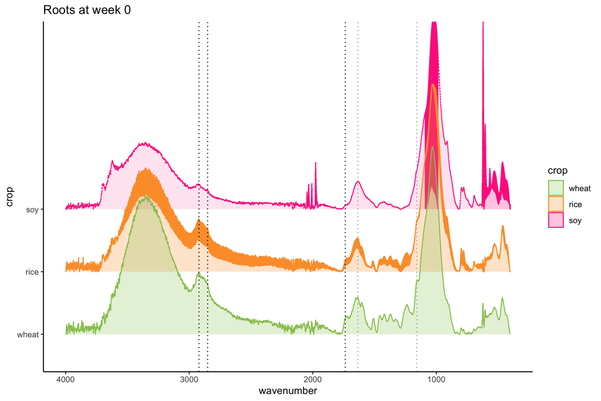

```
FALSE [1] "032" "062" "079" "103"
FALSE # A tibble: 58,786 × 12
FALSE # Groups:   filename [14]
FALSE    wavenumber absorbance filename     source ID    isotope crop  timepoint type
FALSE         <dbl>      <dbl> <chr>        <chr>  <chr>   <dbl> <chr> <chr>     <chr>
FALSE  1      3999.    0       pot001_13C_… pot    001        13 wheat wk0       soil
FALSE  2      3998.    0.00088 pot001_13C_… pot    001        13 wheat wk0       soil
FALSE  3      3997.    0.00143 pot001_13C_… pot    001        13 wheat wk0       soil
FALSE  4      3997.    0.00132 pot001_13C_… pot    001        13 wheat wk0       soil
FALSE  5      3996.    0.00065 pot001_13C_… pot    001        13 wheat wk0       soil
FALSE  6      3996.    0.00001 pot001_13C_… pot    001        13 wheat wk0       soil
FALSE  7      3995.    0       pot001_13C_… pot    001        13 wheat wk0       soil
FALSE  8      3994.    0.00075 pot001_13C_… pot    001        13 wheat wk0       soil
FALSE  9      3994.    0.00221 pot001_13C_… pot    001        13 wheat wk0       soil
FALSE 10      3993.    0.00375 pot001_13C_… pot    001        13 wheat wk0       soil
FALSE # ℹ 58,776 more rows
FALSE # ℹ 3 more variables: run_date <chr>, notes <lgl>, nabs <dbl>
```

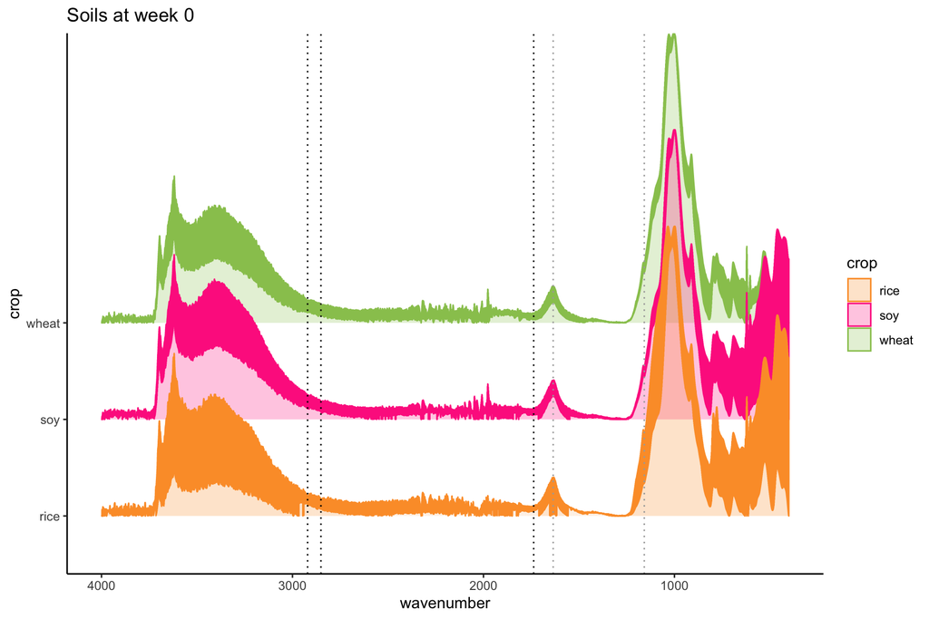

```
FALSE [1] "001" "012" "027" "028" "032" "050" "062" "079" "103"
```

### Week 10

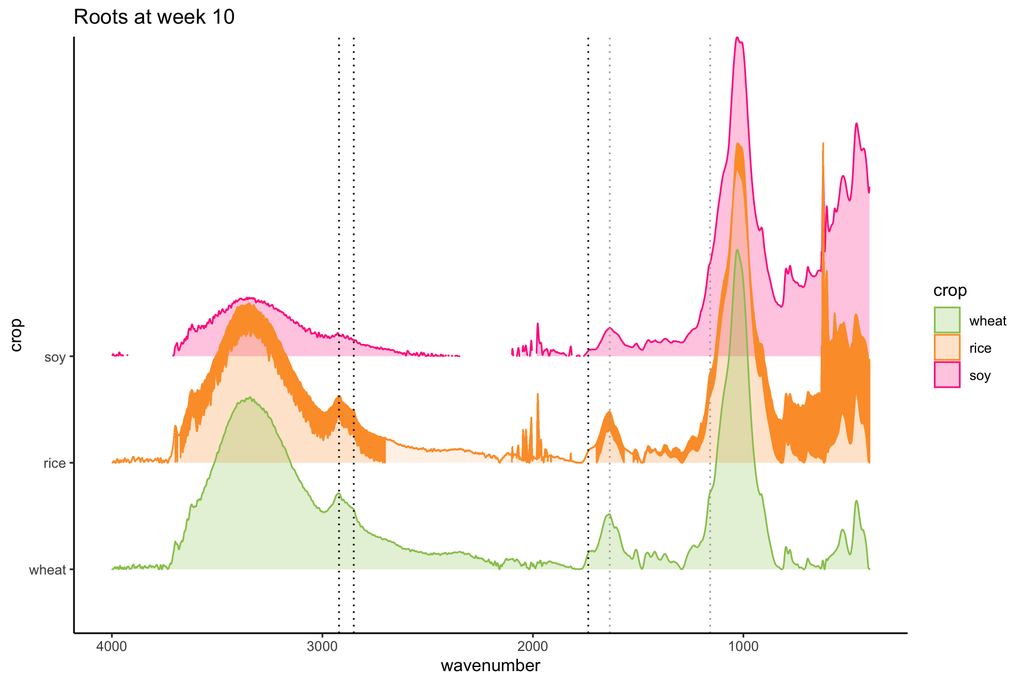

```
#> [1] "053" "055" "080"
```

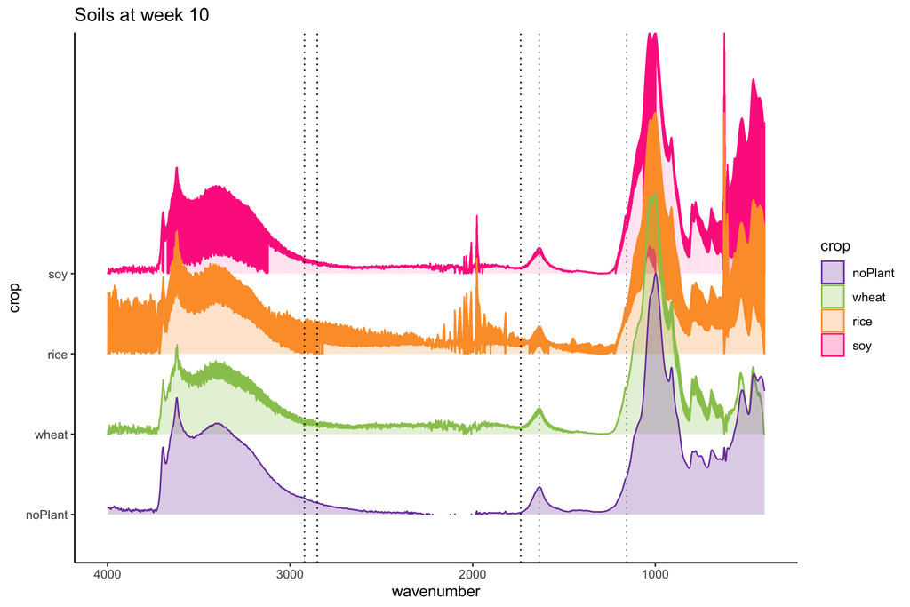

```
#> [1] "029" "053" "055" "072" "080" "087" "094" "119"
```

## Plotting by crop

According to Martins et al. 2014:

> Major peaks, which can be almost exclusively assigned to suberin, are at 2921 cm<sup>-1</sup>, 2851 cm<sup>-1</sup> and 1737 cm<sup>-1</sup>. The remaining peaks are simultaneously assigned to the fungal cell wall and either to suberin (1158 cm<sup>-1</sup> and 1635 cm<sup>-1</sup>)…

> — Martins, I., Hartmann, D.O., Alves, P.C. et al. Elucidating how the saprophytic fungus Aspergillus nidulans uses the plant polyester suberin as carbon source. BMC Genomics 15, 613 (2014). https://doi.org/10.1186/1471-2164-15-613

1737 = C=O stretch (esters)

### Wheat Roots

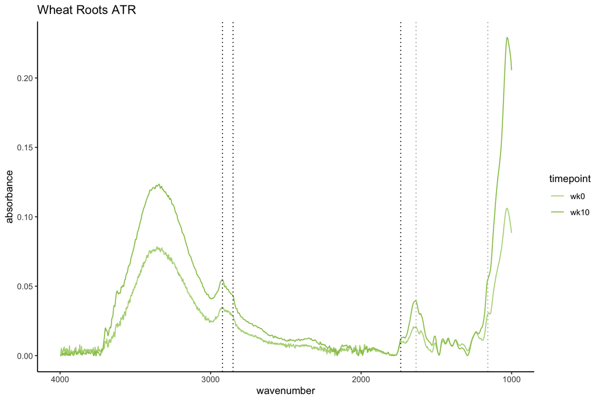

```
#> [1] "032" "053"
```

### rice roots

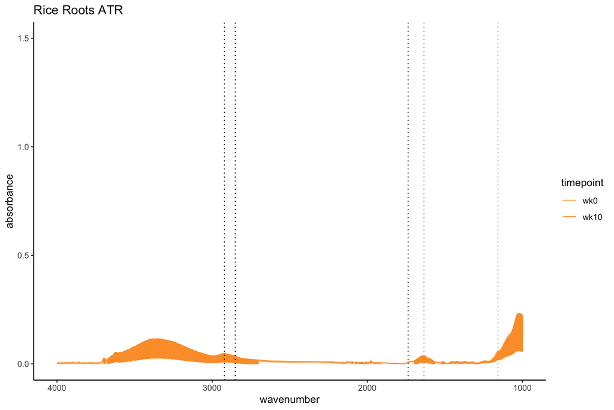

```
#> [1] "055" "079" "103"
```

### soy roots

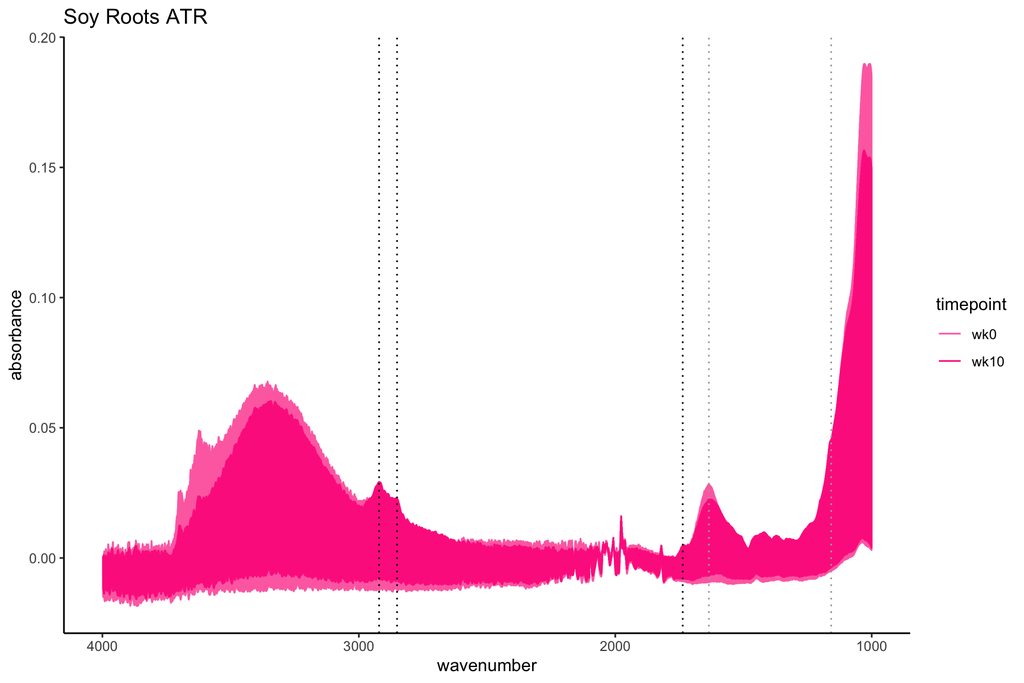

```
#> [1] "062" "080" "094"
```